# Counting Talk at the Supreme Court

Six defensible answers to who talks the most, and one number that turns out to be about a rule

Democracy’s Data

Last updated September 13, 2026 at 10:53a EDT

> *“You could tell from the questioning which way it was going.”*

Reporters write that sentence every term, and there is research behind it: the side that draws the harder questions tends to lose.[^1] Any version of the claim rests on a count, and before anybody can count, somebody has to decide what a question is, whose turn it was, and how long it lasted. This brief asks how much of an apparent fact about nine people survives that decision.

It matters because oral argument is the only part of the Supreme Court’s work an ordinary citizen can watch happen. The Court publishes no video, but it does publish the audio.[^2] Every claim about a hot bench or a silenced advocate is a count somebody made from that tape, and the counts get written up as facts about the justices.

Most of them are not. Ask who talks the most in 6 defensible ways and 3 different justices come first. And the sharpest movement anywhere in the file, a number going from zero to a hundred and a twenty-year silence ending, was not a change in anybody’s behaviour at all.

## The test

Everything below comes from Oyez, a free public archive of the Court’s audio run by Cornell’s Legal Information Institute, Justia and Chicago-Kent College of Law, at https://www.oyez.org. This brief covers 1,409 arguments across the 2005 to 2025 terms — a term is the Court’s working year, named for the October in which it opens — which is every argument the Roberts Court, the Court under Chief Justice John Roberts, has heard, and 363,292 speaking turns inside them. A turn is one person’s uninterrupted stretch of speech, from the moment they start until somebody else does.

This source is the right one for what it is not. The roll-call chapter sets out the clean case, a record in which the act is the data, and names the Supreme Court Database as the courts’ version of it. Almost nothing in that database is an observation: whether a decision was liberal or conservative is a coder’s reading of an opinion. Oral argument is the exception. Oyez publishes the audio aligned with the transcript — each turn’s words carry the second on the tape at which they began and the second at which they ended — one row per speaking turn, with a start and a stop time on every row.

Nobody had to read anything and reach a conclusion to know that Clarence Thomas first asked a question 115.15 seconds into the argument in *Williams v. Reed*. Oyez is a teaching archive, built so the public could hear the Court rather than read about it. Using it as a measuring instrument is a repurposing, and a fortunate one: an archive made for listeners keeps exactly the details a count needs.

## The data

Oyez’s record is not a table. Each case holds sections, each section holds turns, and this is one turn with the fields it carries.

| Field | Value |
| --- | --- |
| case | Williams v. Reed (23-191, 2024 term) |
| speaker | Clarence Thomas |
| role | Associate Justice of the Supreme Court of the United States |
| start | 115.15 seconds in |
| stop | 135.735 seconds in |
| seconds of floor | 20.59 |
| words | 58 |
| text | Well, what’s the difference? If it’s – if – if – let’s say – and I’m just speculating –… |

`start` and `stop` are seconds, and the arithmetic on them is the whole method. Subtract one from the other and that turn held the floor for 20.59 seconds. Do the same for every turn Clarence Thomas took in that argument — 3 of them, counting the courtesy turns the tables below leave out — and they add up to 48.2 seconds of the argument’s 75.8 minutes, carrying 120 words. Those three numbers, turns, seconds and words, for one justice in one argument, are the raw material of every ranking in this brief; the measures below average them over a term.

**Nobody decided the seconds.** A machine lined the words up against the tape. That is a real difference from a coded column, and it is smaller than it looks.

**A turn is a decision, and a person made it.** The timestamps are attached to units a court reporter drew. Somebody decided where one turn stops and the next begins, whether an interruption counts as a turn of its own, and which of two people talking across each other got the words. Oyez then attached a name to every turn, which is a second judgment on top of the first. None of that is sloppiness: there is no way to turn a recording of nine people interrupting each other into rows without deciding what a row is. **The judgments moved upstream**, out of the column you want to analyse and into the definition of the row.

Two kinds of justice turn are not participation, and this build drops them from every count below: gavelling an argument in or out, and courtesy, which is “Thank you, counsel” and “No questions.” The Chief Justice opens and closes every argument, so counting those would make whoever holds that office the busiest questioner on the Court by arithmetic rather than by behaviour. Dropping them removes 2.63% of all turns here.

Here are the 6 ways of asking who talks the most, over the 2022 to 2025 terms, the window with the current nine justices in it. Every one of them is defensible, and every one is computed from the same turns.

| Measure | What it counts |
| --- | --- |
| turns per argument | how often a justice takes the floor |
| words per argument | how much a justice says in an argument |
| words per turn | how long a justice goes when they do speak |
| seconds of floor per argument | how much of the clock a justice personally holds |
| share of all justice words | a justice’s share of everything the justices said |
| share of the argument clock | a justice’s share of the whole argument, lawyers included |

> **Before you look at the figure, commit to a number.** Take the nine justices and rank them by how many words they say in an average argument. Now rank them instead by how many seconds of the clock they personally hold. Those sound like the same question asked twice. Across all 6 measures, **how many places does the biggest mover travel**, from their best rank to their worst? Then say how many of the nine hold exactly the same rank on all 6.

## What it says about democracy

Hover a line to follow one justice. Click to keep them raised.

Every line is one justice, holding the same identity across all 6 columns. The table under the figure carries every value plotted here.

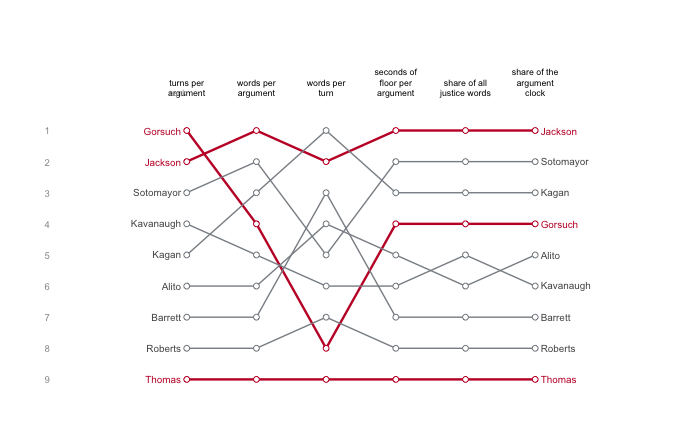

**Figure 1. The same nine justices, ranked 6 ways, on the 2022 to 2025 terms.** A bump chart fits this question because what matters is not any one number but whether a justice’s *rank* holds still. Rank 1 is at the top, each line is one justice and keeps its identity across every column, so a line that slopes is a justice whose answer depends on which question you asked. Nine lines is more than the eye can separate by colour, so names sit at both ends of each one. On screen the lines start grey and hovering raises one; in print the three the text discusses are red.

| Justice | Turns per argument | Words per argument | Words per turn | Seconds of floor per argument | Share of all justice words | Share of the argument clock |
| --- | --- | --- | --- | --- | --- | --- |
| Gorsuch | 1 | 4 | 8 | 4 | 4 | 4 |
| Jackson | 2 | 1 | 2 | 1 | 1 | 1 |
| Sotomayor | 3 | 2 | 5 | 2 | 2 | 2 |
| Kavanaugh | 4 | 5 | 6 | 6 | 5 | 6 |
| Kagan | 5 | 3 | 1 | 3 | 3 | 3 |
| Alito | 6 | 6 | 4 | 5 | 6 | 5 |
| Barrett | 7 | 7 | 3 | 7 | 7 | 7 |
| Roberts | 8 | 8 | 7 | 8 | 8 | 8 |
| Thomas | 9 | 9 | 9 | 9 | 9 | 9 |

Neil Gorsuch is the whole argument in one line. Ranked by turns per argument, Gorsuch is **first** on the Court. Ranked by words per turn, the same justice over the same terms is **eighth**. Nothing about the underlying turns changed, and the question changed by a few words.

**7 places is the widest swing, and 8 of the 9 justices move at all.** Taking the floor often and holding it a long time are different habits. A justice who fires twenty short questions and one who asks three long ones can end with the same word count and opposite rankings on everything else.

**The ends of the table do not move**, and that matters more. Ketanji Brown Jackson is in the top three on every measure, and Clarence Thomas is last on every measure. The scrambling is all in the middle, where the differences between justices are small enough that the choice of measure decides the order.

There is an unusually clean outside check on that. Lee Epstein and Eric Posner built the same kind of file from Westlaw transcripts, a commercial legal database, rather than from Oyez.[^3] They ran 18 measures rather than 6, and reported the same justice in the top three on 17 of them.

| Quantity | Epstein and Posner report | This build, from Oyez |
| --- | --- | --- |
| Arguments in the 2005-2025 terms | 1,425 | 1,409 |
| Speaking turns, before the two exclusions | 368,369 | 363,292 |
| Speaking turns, after them | 353,278 | 353,755 |
| Justice words per argument, 2005 term | 3,866 | 3,867 |
| Justice words per argument, 2025 term | 5,802 | 5,855 |
| Arguments with at least one silent justice | 1,105 | 1,098 |
| Longest argument, in minutes | 193 | 192 |

Two teams, two sources, two parsers written by people who never spoke, and the justice word count for the 2005 term differs by 1 word in 3,867. The thing being counted survives who counts it, which is not true of most measures in this book. The share of decisions coded conservative in the Supreme Court chapter would not survive a second team recoding it. **Word counts survive because a word is not a judgment.**

Everything so far has been a fact about nine people. The next number is not.

On 4 May 2020 the Court heard argument by telephone for the first time, and gave itself a rule it had never had.[^4] After the advocate’s opening, the justices would question one at a time, in order of seniority, with the Chief going first. That rule leaves a mark anybody can measure. If the justices ask their first questions in seniority order, the list of who spoke first, second and third is sorted.

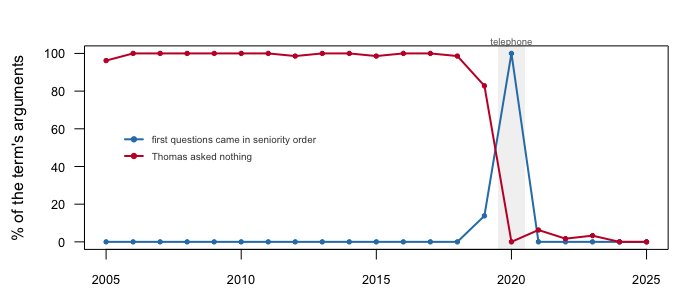

**Figure 2. Two shares of each term’s arguments.** In blue, the share where the justices asked their first questions in exact seniority order. In red, the share where Justice Thomas asked nothing. Both are divided by the same bottom number, the arguments heard that term, which is why they belong on one axis. The shaded band is the 2020 term, argued by telephone.

**For 14 straight terms the blue line is exactly zero. In the telephone term it is 100.0%.** Then the Court went back to its courtroom and it fell to 0.0% again. The 2019 term is the seam and reads 13.8%, because it was argued in the courtroom until March and by telephone in May.

Nothing about the nine people produced that. They did not become more deferential to seniority in 2020 and abandon it in 2021. **An administrative decision about how to run a hearing on a conference call moved a social statistic from zero to a hundred and back.**

The red line is Justice Thomas. He asked nothing in 99.4% of the arguments he sat for through 2018, and in 10 of those terms he asked nothing in a single argument. He was famous for it, and the fame came with explanations about temperament and about what he thought argument was for. Then the format handed every justice a turn by name, and his silence went to 0.0%. It has stayed near there since, at 1.9% across every argument.

**Whatever that silence had been, it was at least partly a fact about a room in which you had to interrupt to be heard.** A measure of a person turned out to be measuring an arrangement of chairs. **Ask of any statistic about people: could a rule have produced this?** Here the answer was yes, and it hid behind a sentence everybody found easy to believe.

## What this brief cannot tell you

**Nothing here measures persuasion.** Talking is not the same as changing an outcome, and the justice who says least may be the one who decides the case. This brief can tell you who held the floor. It cannot tell you who won the argument. The claim it opened with, that the questioning shows which way a case is going, needs the outcomes joined to the transcripts and a design this file does not supply.

**A turn is a transcription decision**, drawn by a court reporter, so every count of turns inherits a definition nobody here chose. The rule for dropping gavel and courtesy turns is this build’s own, and it removes a different share than Epstein and Posner’s does.

**The bench roster is a period, not a day.** Counting silence needs a roster, and a transcript has none: a justice who says nothing leaves no row in it. The roster here is Oyez’s record of who was sitting over a stretch of terms, so a justice recused from one case reads as one who kept quiet in it.

**The seniority measure looks only at first questions.** The Court kept a seniority round when it returned to the courtroom, but put it at the end of each advocate’s time rather than the start.[^5] A measure reading zero in 2021 and zero in 2015 is not saying the same thing about those two terms.

## What you should have learned

- Six reasonable ways to ask who talks the most produce 3 different answers to the question, and the widest swing by one justice is 7 places.
- The extremes hold and the middle does not: Ketanji Brown Jackson is top three on every measure, Clarence Thomas is last on every one, and 8 of 9 justices move in between.
- Arguments got longer without the justices getting faster, from 60.2 minutes in 2005 to 88.8 in 2025 at a near-constant 65.9 words a minute.
- A rule change moved the share of arguments questioned in seniority order from zero to 100.0% and back, and ended a silence that had run 99.4% of one justice’s arguments.
- Two teams counting different transcripts agreed to within 1 word in 3,867, because a word count is not a coding judgment.

## Extensions

None of these is answered above, and every one can be answered from the tables the Sources section hands over.

- `measures.csv` ranks the justices 6 ways, in `measure`, `value` and `rank`. Find the justice whose `rank` changes most. Which measure would you use in a sentence, and what would you be claiming?
- `arguments.csv` has `minutes`, `turns` and `justice_words` per case, with a `regime` column. Average each of them inside each `regime`. What did the rule change actually change?
- `silence.csv` has `pct_silent` per justice per `term`. Sort it, find the justices who said nothing most often, and check whether that changed under the new format.
- `order.csv` gives `pct_in_seniority_order` by `term`, and `speakers.csv` gives each justice a `seniority_rank`. Who gains from a fixed speaking order, and who loses?

Two stretch ideas point past the spreadsheet. Oyez covers argument back to 1955, so download a term from before the Roberts Court and ask whether argument length was already growing. And the Court’s own site posts same-day audio, so count a term of it yourself and compare your totals against `arguments.csv`.

## Sources

**Data**

- **Oyez**, oral argument audio aligned to transcripts, 2005-2025 terms. https://www.oyez.org, free and public; the same records in a form for software are at https://api.oyez.org. Each transcript is broken into turns, and every turn carries a start and stop time in seconds. 1,409 arguments and 363,292 turns are read. The bench roster is Oyez’s record of the natural court.

**Compared against, but not used**

- Epstein, L. and Posner, E. A. (2026). *Two Decades of Oral Argument in the Supreme Court, 2005-2025 Terms.* Report prepared for the *New York Times*, 12 August 2026. https://epstein.wustl.edu/s/oralargumentreport.pdf The underlying corpus is built from Westlaw transcripts and is not public, so the figures quoted from it are read off the report and labelled in the table that uses them.

**Academic literature**

- Epstein, L. and Posner, E. A. (2026). “What Is Oral Argument in the Supreme Court For?” https://papers.ssrn.com/sol3/papers.cfm?abstract_id=7227018
- Epstein, L., Landes, W. M. and Posner, R. A. (2010). “Inferring the Winning Party in the Supreme Court from the Pattern of Questioning at Oral Argument.” *Journal of Legal Studies* 39(2): 433-467. https://www.jstor.org/stable/10.1086/651511
- Johnson, T. R., Wahlbeck, P. J. and Spriggs, J. F. (2006). “The Influence of Oral Arguments on the U.S. Supreme Court.” *American Political Science Review* 100(1): 99-113. https://doi.org/10.1017/S0003055406062034
- Supreme Court of the United States, press release of 13 April 2020 on argument by telephone, https://www.supremecourt.gov/publicinfo/press/pressreleases/pr_04-13-20; *Guide for Counsel* (2024), on the seniority round, https://www.supremecourt.gov/casehand/Guide%20for%20Counsel%202024.pdf; argument audio, https://www.supremecourt.gov/oral_arguments/argument_audio.aspx

**The data itself**

Every figure above is drawn from these tables. They are plain CSV, they open in a spreadsheet, and they are yours to take further.

`arguments.csv`, `exhibit.csv`, `justice_terms.csv`, `measures.csv`, `order.csv`, `silence.csv`, `speakers.csv`, `totals.csv`

One more file is not data about the subject – it is how this chapter checked its own work: `checks.csv`, the arithmetic verified before anything was drawn.

Rebuild this data yourself, with an AI assistant

```
I want to rebuild a public dataset from its original source, without any
starting files. Please do the following and show your work.

THE SOURCE. Oyez — a joint project of Cornell's Legal Information
Institute, Justia and Chicago-Kent College of Law — publishes every
Supreme Court oral argument as audio aligned to a transcript, turn by
turn, each turn timestamped to the hundredth of a second. The API is
open, no key or account. Asking
https://api.oyez.org/cases?per_page=0&filter=term:2005
lists a term's cases; each case's own JSON names its argument audio,
and the argument's JSON holds the whole transcript. Do this for the
2005 through 2025 terms — twenty-one terms, about 1,500 cases, roughly
half a gigabyte in all.

HOW TO DOWNLOAD IT. Case by case, patiently. There is no bulk file, so
this is thousands of small requests: pause between them, and cache
everything that arrives so a re-run never asks twice.

WHAT TO BUILD.
1. One row per argument: date, how long it ran, how many turns, how
   many words, how many justices spoke.
2. Per justice per term: turns, words, and seconds — after dropping
   the turns that are not participation, meaning the Chief's
   gavel-work ("We'll hear argument this morning in...") and pure
   courtesy ("Thank you, counsel"). Counting those would crown the
   Chief the most talkative justice by construction.

CHECK YOUR WORK. The copy this book used was downloaded in August 2026.
If your rebuild matches it, you should find:
- 1,409 arguments parsed — against the 1,425 counted by Epstein and
  Posner's published report, which is built from licensed Westlaw
  transcripts nobody can redistribute
- 363,292 turns read, with 2.63% dropped as administrative or courtesy
- the longest argument runs 192.3 minutes
Oyez keeps posting arguments as terms proceed; a later download has more
rows because the Court kept sitting, not because you made an error.
```

[^1]: Lee Epstein, William M. Landes and Richard A. Posner, “Inferring the Winning Party in the Supreme Court from the Pattern of Questioning at Oral Argument,” *Journal of Legal Studies* 39, no. 2 (2010): 433–467, https://www.jstor.org/stable/10.1086/651511; Timothy R. Johnson, Paul J. Wahlbeck and James F. Spriggs, “The Influence of Oral Arguments on the U.S. Supreme Court,” *American Political Science Review* 100, no. 1 (2006): 99–113, https://doi.org/10.1017/S0003055406062034.
[^2]: The Court’s own archive of argument audio: https://www.supremecourt.gov/oral_arguments/argument_audio.aspx.
[^3]: Lee Epstein and Eric A. Posner, *Two Decades of Oral Argument in the Supreme Court, 2005–2025 Terms*, report prepared for the *New York Times*, 12 August 2026, https://epstein.wustl.edu/s/oralargumentreport.pdf.
[^4]: The Court’s announcement of 13 April 2020 that May’s arguments would be heard by telephone conference: https://www.supremecourt.gov/publicinfo/press/pressreleases/pr_04-13-20.
[^5]: The Court’s *Guide for Counsel* says that once an advocate’s time has expired, “each Justice will have the opportunity to question that attorney individually,” in order of seniority: https://www.supremecourt.gov/casehand/Guide%20for%20Counsel%202024.pdf.